# Modelldiagnostik & Modellkomplexität

Praktische Übungen zum GRK2700 Statistik-Workshop

Autor:in

Dr. Dominic Schmitz

Veröffentlichungsdatum

25. August 2026

```r
library(ggplot2)
library(lme4)
library(lmerTest)
library(performance)
library(SfL)

data("data_l", package = "SfL")
dat <- data_l

dat$condition <- factor(dat$condition)
dat$length_z <- as.numeric(scale(dat$length))
```

**HinweisZiel dieses Blocks**

Ein Modell zu berechnen ist nur der erste Schritt. In diesem Block geht es deshalb weniger darum, noch eine neue Modellklasse kennenzulernen, sondern darum, **bestehende Modelle kritisch zu prüfen**.

Drei Fragen begleiten uns durch die Übungen:

1. Passt die **Modellform** angemessen zu den Daten?
2. Wird das Ergebnis von **einzelnen Beobachtungen** dominiert?
3. Ist die **Modellkomplexität** angemessen?

# 1 Residuen und Modellform

## 1.1 Residuen verstehen

**HinweisAufgabe 1 · Was ist ein Residuum?**

geführt

Wir beginnen mit einem einfachen Modell aus dem Lexical-Decision-Datensatz:

```r
m1 <- lm(
  RT ~ frequency_z + length_z + condition,
  data = dat
)
```

Berechne für die **erste Beobachtung**:

1. den tatsächlich beobachteten Wert,
2. den vom Modell vorhergesagten Wert,
3. das Residuum,
4. und überprüfe anschließend mit `residuals(m1)[1]`, ob deine Rechnung stimmt.

**TippLösung**

```r
observed_1 <- dat$RT[1]
predicted_1 <- fitted(m1)[1]
residual_1 <- observed_1 - predicted_1

c(
  observed = observed_1,
  predicted = predicted_1,
  residual = residual_1,
  residual_from_R = residuals(m1)[1]
)
```

```
         observed       predicted.1        residual.1 residual_from_R.1
         431.0000          695.0488         -264.0488         -264.0488
```

Ein **positives Residuum** bedeutet: Die beobachtete RT ist höher als vom Modell vorhergesagt.

Ein **negatives Residuum** bedeutet: Die beobachtete RT ist niedriger als vom Modell vorhergesagt.

## 1.2 Der wichtigste Diagnoseplot

**HinweisAufgabe 2 · Residuen gegen vorhergesagte Werte**

geführt

Erstelle einen Dataframe mit

- den vorhergesagten Werten des Modells und
- den Residuen.

Visualisiere anschließend Residuen gegen vorhergesagte Werte und ergänze

- eine horizontale Linie bei 0 und
- eine LOESS-Kurve.

Was möchtest du bei einem angemessen spezifizierten Modell **nicht** sehen?

**TippLösung**

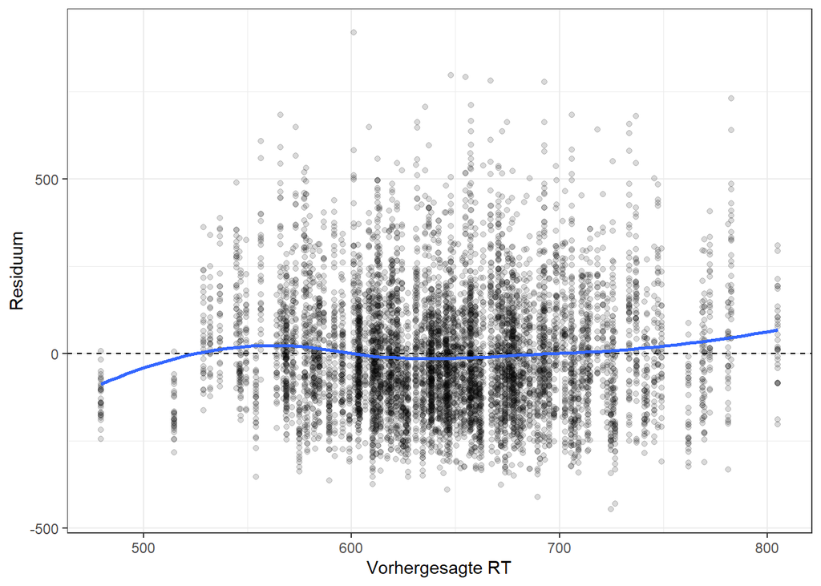

```r
diag_dat <- data.frame(
  fitted = fitted(m1),
  residual = residuals(m1)
)

ggplot(
  diag_dat,
  aes(x = fitted, y = residual)
) +
  geom_point(alpha = .15) +
  geom_hline(
    yintercept = 0,
    linetype = "dashed"
  ) +
  geom_smooth(
    method = "loess",
    formula = y ~ x,
    se = FALSE
  ) +
  theme_bw() +
  labs(
    x = "Vorhergesagte RT",
    y = "Residuum"
  )
```

Problematisch wären insbesondere

- systematische Krümmungen,
- stark veränderliche Streuung,
- eine deutlich von 0 abweichende LOESS-Linie,
- isolierte extreme Beobachtungen.

Wichtig: Ein einzelner „nicht perfekter“ Punkt macht ein Modell noch nicht problematisch. Entscheidend sind **systematische Muster**.

## 1.3 Ein absichtlich zu einfaches Modell

Wir erzeugen nun Daten, bei denen wir bereits wissen, dass der wahre Zusammenhang gekrümmt ist.

```r
set.seed(20260825)

curve_dat <- data.frame(
  x = seq(-3, 3, length.out = 180)
)

curve_dat$y <- (
  500 +
  20 * curve_dat$x +
  35 * curve_dat$x^2 +
  rnorm(nrow(curve_dat), mean = 0, sd = 25)
)
```

**HinweisAufgabe 3 · Underfitting sichtbar machen**

angewandt

1. Schätze zunächst ein einfaches lineares Modell `y ~ x`.
2. Erstelle den Residuen-vs.-Fitted-Plot.
3. Beschreibe das Muster.
4. Was sagt dir dieses Muster über die Modellform?

**TippLösung**

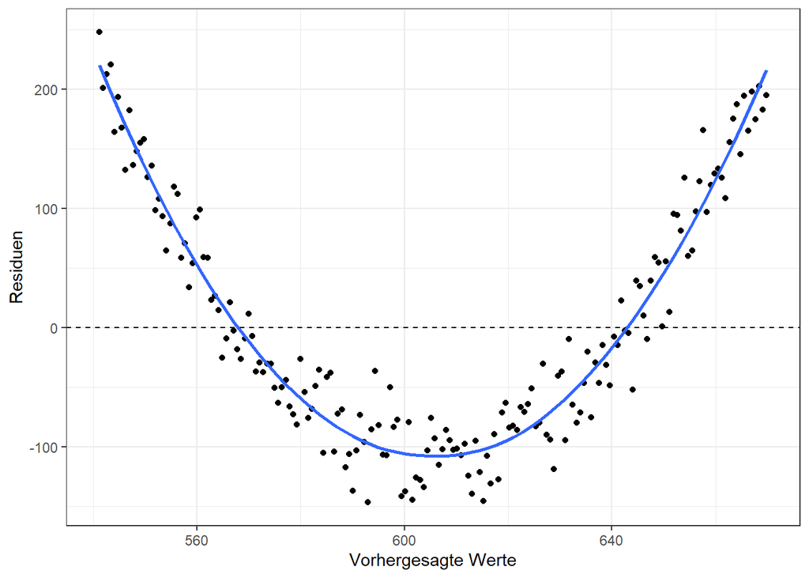

```r
m_curve_linear <- lm(
  y ~ x,
  data = curve_dat
)

curve_diag <- data.frame(
  fitted = fitted(m_curve_linear),
  residual = residuals(m_curve_linear)
)

ggplot(
  curve_diag,
  aes(x = fitted, y = residual)
) +
  geom_point() +
  geom_hline(
    yintercept = 0,
    linetype = "dashed"
  ) +
  geom_smooth(
    method = "loess",
    formula = y ~ x,
    se = FALSE
  ) +
  theme_bw() +
  labs(
    x = "Vorhergesagte Werte",
    y = "Residuen"
  )
```

Die systematische Krümmung zeigt: Das Modell lässt **systematische Struktur** in den Residuen zurück.

Das Problem ist nicht, dass die Daten „schlecht“ sind, sondern dass die Modellform **zu restriktiv** ist.

**HinweisAufgabe 4 · Die Modellform anpassen**

angewandt

Erweitere das Modell um einen quadratischen Term:

```r
y ~ x + I(x^2)
```

1. Schätze das Modell.
2. Erstelle erneut den Residuen-vs.-Fitted-Plot.
3. Vergleiche die beiden Diagnoseplots.
4. Vergleiche zusätzlich die beiden Modelle mit `anova()`.

**TippLösung**

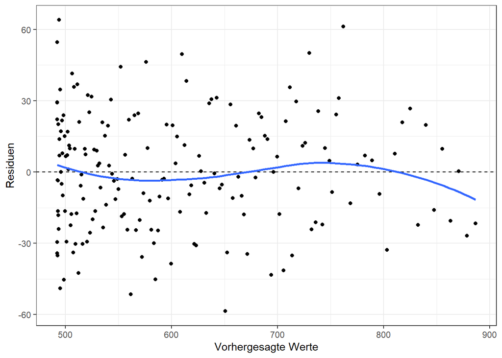

```r
m_curve_quadratic <- lm(
  y ~ x + I(x^2),
  data = curve_dat
)

curve_diag2 <- data.frame(
  fitted = fitted(m_curve_quadratic),
  residual = residuals(m_curve_quadratic)
)

ggplot(
  curve_diag2,
  aes(x = fitted, y = residual)
) +
  geom_point() +
  geom_hline(
    yintercept = 0,
    linetype = "dashed"
  ) +
  geom_smooth(
    method = "loess",
    formula = y ~ x,
    se = FALSE
  ) +
  theme_bw() +
  labs(
    x = "Vorhergesagte Werte",
    y = "Residuen"
  )
```

```r
anova(
  m_curve_linear,
  m_curve_quadratic
)
```

```
Analysis of Variance Table

Model 1: y ~ x
Model 2: y ~ x + I(x^2)
  Res.Df     RSS Df Sum of Sq      F    Pr(>F)
1    178 1852662
2    177  104564  1   1748098 2959.1 < 2.2e-16 ***
---
Signif. codes:  0 '***' 0.001 '**' 0.01 '*' 0.05 '.' 0.1 ' ' 1
```

Das komplexere Modell ist hier inhaltlich gerechtfertigt, weil die Daten eine Struktur enthalten, die das lineare Modell nicht darstellen konnte.

**VorsichtMerke**

Ein auffälliger Diagnoseplot bedeutet nicht automatisch:

> „Variable transformieren!“

Er bedeutet zunächst:

> **Das Modell bildet einen Aspekt der Daten nicht angemessen ab. Warum?**

Die sinnvolle Reaktion hängt von Ursache, Forschungsfrage und Modellklasse ab.

## 1.4 Extra: automatische Checks kritisch lesen

**HinweisExtra 1 · performance als Unterstützung**

extra

Nutze für `m1`:

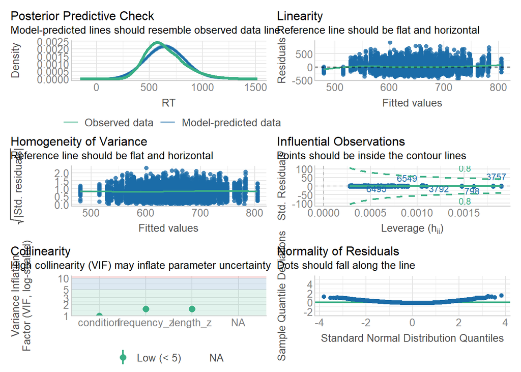

```r
check_model(m1)
```

Vergleiche die dort dargestellten Informationen mit dem selbst erstellten Residuenplot.

Welche Information erhältst du dadurch schneller? Was ersetzt der automatische Check **nicht**?

**TippLösung**

`check_model()` ist praktisch, um mehrere Diagnoseinformationen kompakt zu visualisieren.

Es ersetzt aber nicht die inhaltliche Entscheidung,

- ob ein Muster tatsächlich relevant ist,
- wodurch es entstehen könnte,
- und welche Reaktion für die Forschungsfrage sinnvoll wäre.

Diagnostik ist kein Ampelsystem.

# 2 Auffällige und einflussreiche Beobachtungen

## 2.1 Outlier, Leverage und Influence auseinanderhalten

**HinweisAufgabe 5 · Drei unterschiedliche Begriffe**

geführt

Ordne den Begriffen die passende Beschreibung zu:

- **Outlier**
- **High-leverage point**
- **Influential observation**

Beschreibungen:

A. ungewöhnliche Werte der Prädiktoren  
B. ungewöhnlich großes Residuum  
C. Beobachtung verändert die geschätzten Modellparameter deutlich

**TippLösung**

- **Outlier** → B
- **High-leverage point** → A
- **Influential observation** → C

Die Kategorien können sich überschneiden, müssen es aber nicht.

Insbesondere gilt:

> **Outlier ≠ automatisch influential.**

## 2.2 Eine einflussreiche Beobachtung konstruieren

```r
set.seed(20260825)

influence_dat <- data.frame(
  x = 1:40
)

influence_dat$y <- (
  10 +
  3 * influence_dat$x +
  rnorm(40, mean = 0, sd = 6)
)

influence_dat <- rbind(
  influence_dat,
  data.frame(
    x = 43,
    y = 180
  )
)
```

**HinweisAufgabe 6 · Wo sitzt der auffällige Punkt?**

geführt

Visualisiere `y` in Abhängigkeit von `x` und füge eine Regressionsgerade ein.

Welcher Punkt fällt auf? Ist er nur aufgrund seines `y`-Wertes auffällig, nur aufgrund seines `x`-Wertes oder aufgrund beider Aspekte?

**TippLösung**

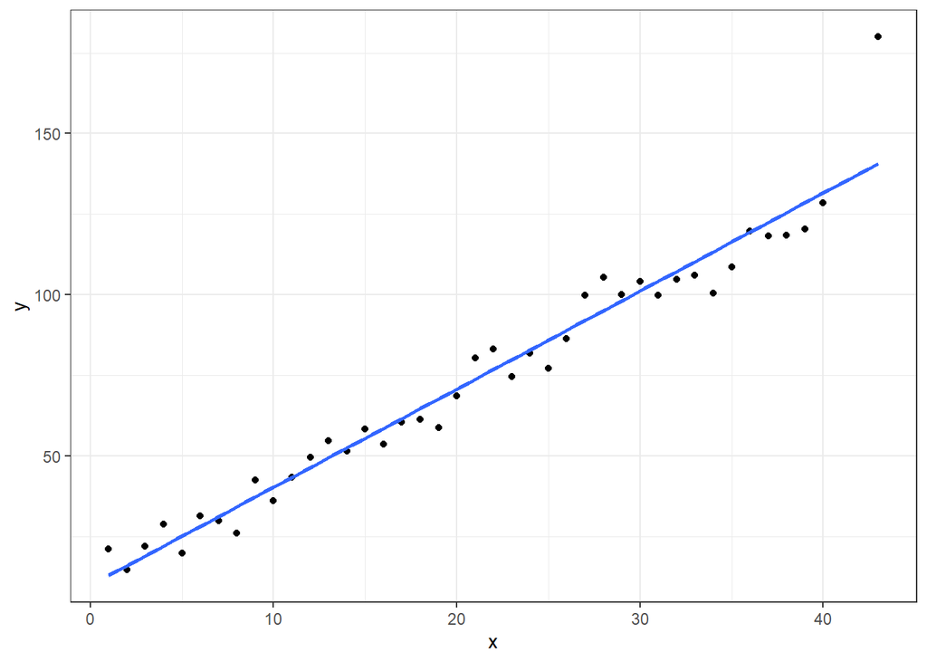

```r
ggplot(
  influence_dat,
  aes(x = x, y = y)
) +
  geom_point() +
  geom_smooth(
    method = "lm",
    formula = y ~ x,
    se = FALSE
  ) +
  theme_bw()
```

Die letzte Beobachtung liegt sowohl bei einem ungewöhnlich hohen `x`-Wert als auch deutlich außerhalb des sonstigen Musters.

Sie hat daher das Potenzial, einen starken Einfluss auf die Regressionsgerade auszuüben.

## 2.3 Cook’s Distance

**HinweisAufgabe 7 · Einfluss quantifizieren**

angewandt

1. Schätze `y ~ x`.
2. Berechne Cook’s Distance für jede Beobachtung mit `cooks.distance()`.
3. Finde die Beobachtung mit dem größten Wert.
4. Visualisiere Cook’s Distance für alle Beobachtungen.

**TippLösung**

```r
m_full <- lm(
  y ~ x,
  data = influence_dat
)

cook <- cooks.distance(m_full)

which.max(cook)
```

```
41
41
```

```r
max(cook)
```

```
[1] 1.456458
```

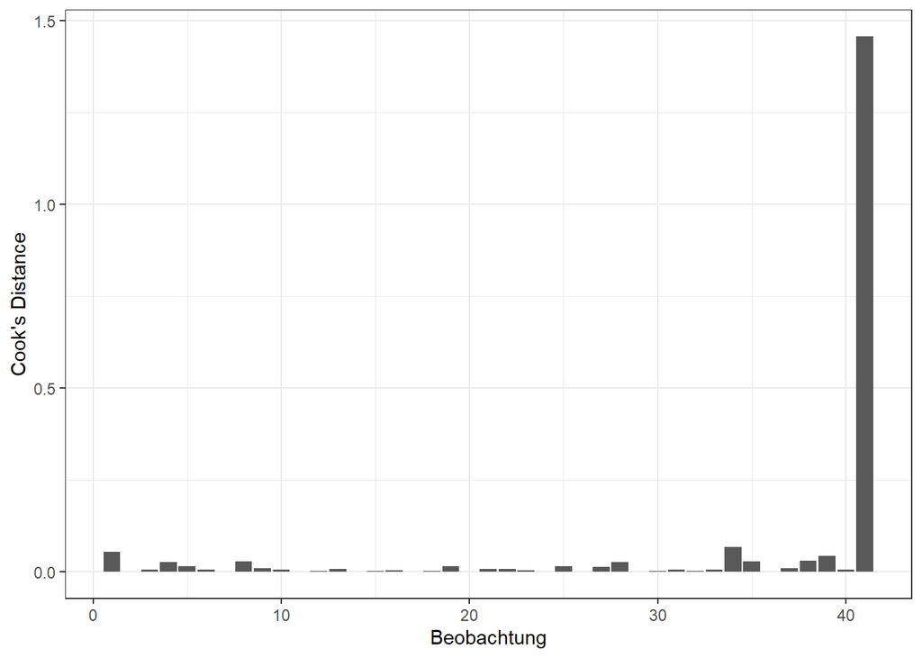

```r
cook_dat <- data.frame(
  observation = seq_along(cook),
  cooks_distance = cook
)

ggplot(
  cook_dat,
  aes(x = observation, y = cooks_distance)
) +
  geom_col() +
  theme_bw() +
  labs(
    x = "Beobachtung",
    y = "Cook's Distance"
  )
```

Cook’s Distance fragt vereinfacht:

> Wie stark würde sich das Modell verändern, wenn diese Beobachtung nicht vorhanden wäre?

**VorsichtKeine Löschregel**

Ein großer Cook’s-D-Wert ist **kein automatischer Grund**, eine Beobachtung zu entfernen.

Zuerst fragen wir:

- Ist die Beobachtung ein Datenfehler?
- Ist sie inhaltlich plausibel?
- Warum hat sie so großen Einfluss?
- Ändert sie unsere wissenschaftliche Schlussfolgerung?

## 2.4 Sensitivitätsanalyse

**HinweisAufgabe 8 · Modell mit und ohne Beobachtung**

angewandt

Entferne **nur für eine Sensitivitätsanalyse** die Beobachtung mit der größten Cook’s Distance.

Vergleiche anschließend:

1. Intercept,
2. Steigung von `x`,
3. wissenschaftliche Interpretation.

Wichtig: Die Aufgabe lautet nicht „Lösche den Outlier“, sondern „Prüfe, wie abhängig das Ergebnis von dieser Beobachtung ist“.

**TippLösung**

```r
most_influential <- which.max(
  cooks.distance(m_full)
)

m_without <- lm(
  y ~ x,
  data = influence_dat[-most_influential, ]
)

coef(m_full)
```

```
(Intercept)           x
   9.812212    3.043406
```

```r
coef(m_without)
```

```
(Intercept)           x
  12.231986    2.877415
```

Die Koeffizienten müssen nicht identisch bleiben, damit ein Ergebnis robust ist.

Entscheidend ist:

> Verändert sich die **wissenschaftliche Interpretation** fundamental?

## 2.5 Zurück zu den Lexical-Decision-Daten

**HinweisAufgabe 9 · Auffällige Beobachtungen im echten Modell**

angewandt

Nutze wieder `m1`.

1. Berechne standardisierte Residuen mit `rstandard()`.
2. Finde die fünf Beobachtungen mit dem größten absoluten standardisierten Residuum.
3. Berechne Cook’s Distance.
4. Sind die größten Residuen automatisch auch die Beobachtungen mit der größten Cook’s Distance?

**TippLösung**

```r
std_resid <- rstandard(m1)
cook_m1 <- cooks.distance(m1)

largest_residuals <- order(
  abs(std_resid),
  decreasing = TRUE
)[1:5]

largest_cook <- order(
  cook_m1,
  decreasing = TRUE
)[1:5]

largest_residuals
```

```
[1] 6495 6747 4191 6803 1255
```

```r
largest_cook
```

```
[1] 3757 6495 6549 3792  798
```

```r
dat[largest_residuals, ]
```

```
     subject item condition    group frequency_z length trial   RT accuracy
6495     S55 W015 unrelated training  0.63763660      4    41 1520        1
6747     S57 W027 unrelated training  0.25115352      6    92 1445        1
4191     S35 W111 unrelated training  0.08105208      6    23 1446        1
6803     S57 W083 unrelated training  0.16549145      7    77 1449        1
1255     S11 W055 unrelated  control -0.85659056      6   112 1471        0
     neighbourhood neighbourhood_z    length_z
6495            13     0.325211914 -1.77336235
6747            11    -0.336236046 -0.09112139
4191            12    -0.005512066 -0.09112139
6803            14     0.655935894  0.74999909
1255            11    -0.336236046 -0.09112139
```

```r
dat[largest_cook, ]
```

```
     subject item condition    group frequency_z length trial   RT accuracy
3757     S32 W037   related training  -1.1890454     10    12 1314        1
6495     S55 W015 unrelated training   0.6376366      4    41 1520        1
6549     S55 W069 unrelated training  -2.3061455      8    68 1514        1
3792     S32 W072 unrelated training  -1.8666946      6     6 1391        1
798      S07 W078   related  control  -1.4933336     10    46 1248        0
     neighbourhood neighbourhood_z    length_z
3757             9      -0.9976840  3.27336053
6495            13       0.3252119 -1.77336235
6549             6      -1.9898559  1.59111957
3792             8      -1.3284080 -0.09112139
798              8      -1.3284080  3.27336053
```

Die Listen müssen nicht identisch sein.

Das demonstriert praktisch:

> Ein großes Residuum allein bestimmt nicht, wie stark eine Beobachtung die Modellschätzung beeinflusst.

**HinweisExtra 2 · Leverage separat betrachten**

extra

Berechne mit `hatvalues(m1)` die Leverage-Werte.

Vergleiche die Beobachtungen mit

- hohem Leverage,
- großen Residuen,
- hoher Cook’s Distance.

Was unterscheidet diese drei Perspektiven?

**TippLösung**

```r
lev <- hatvalues(m1)

head(
  sort(
    lev,
    decreasing = TRUE
  )
)
```

```
        157         397         637         877        1117        1357
0.001898489 0.001898489 0.001898489 0.001898489 0.001898489 0.001898489
```

- **Residual**: Wie weit liegt eine Beobachtung vom vorhergesagten Outcome entfernt?
- **Leverage**: Wie ungewöhnlich ist ihre Kombination von Prädiktorwerten?
- **Cook’s Distance**: Wie stark wirkt die Beobachtung auf die Modellschätzung?

# 3 Modellkomplexität: zu einfach oder zu flexibel?

## 3.1 Underfitting und Overfitting

**HinweisAufgabe 10 · Begriffe anwenden**

geführt

Ordne zu:

**Underfitting**

- relevante Struktur bleibt unmodelliert
- Modell ist zu restriktiv
- systematische Muster können in Residuen verbleiben

**Overfitting**

- Modell wird sehr flexibel
- Zufallsrauschen kann mitmodelliert werden
- Generalisierbarkeit kann leiden

Welches der beiden Probleme hatten wir bei `m_curve_linear`?

**TippLösung**

`m_curve_linear` zeigte **Underfitting**: Ein gekrümmter Zusammenhang wurde durch eine Gerade modelliert.

Das Ziel ist weder das komplizierteste noch das einfachste Modell, sondern eine **angemessene Komplexität**.

## 3.2 Extra: mehr Komplexität ist nicht automatisch besser

**HinweisExtra 3 · Trainingsdaten vs. neue Daten**

extra / vertiefend

Wir simulieren einen Datensatz mit einem relativ einfachen wahren Zusammenhang und teilen ihn in Trainings- und Testdaten.

```r
set.seed(20260825)

complexity_dat <- data.frame(
  x = runif(160, -2, 2)
)

complexity_dat$y <- (
  4 +
  2.5 * complexity_dat$x -
  1.2 * complexity_dat$x^2 +
  rnorm(160, sd = 1.5)
)

train_ids <- sample(
  seq_len(nrow(complexity_dat)),
  size = 110
)

train <- complexity_dat[train_ids, ]
test <- complexity_dat[-train_ids, ]
```

Schätze auf den Trainingsdaten:

1. ein lineares Modell,
2. ein quadratisches Modell,
3. ein sehr flexibles Polynom 8. Grades.

Berechne für jedes Modell den mittleren quadratischen Vorhersagefehler (**MSE**) auf den Testdaten.

Welches Modell generalisiert in diesem konkreten Durchlauf am besten?

**TippLösung**

```r
m_train_linear <- lm(
  y ~ x,
  data = train
)

m_train_quad <- lm(
  y ~ x + I(x^2),
  data = train
)

m_train_flexible <- lm(
  y ~ poly(x, 8, raw = TRUE),
  data = train
)

mse <- function(model, newdata) {
  pred <- predict(
    model,
    newdata = newdata
  )

  mean(
    (newdata$y - pred)^2
  )
}

c(
  linear = mse(m_train_linear, test),
  quadratic = mse(m_train_quad, test),
  flexible = mse(m_train_flexible, test)
)
```

```
   linear quadratic  flexible
 3.023104  1.640839  1.672658
```

Das konkrete Ergebnis hängt durch die Simulation etwas vom Datensatz ab.

Der zentrale Punkt bleibt:

> Ein Modell kann die Trainingsdaten sehr gut beschreiben und trotzdem auf neuen Daten schlechter funktionieren.

Mehr Flexibilität ist also nicht kostenlos.

# 4 Gemischte Modelle: Konvergenz und Singularität

## 4.1 Konvergenz ist Teil des Outputs

**HinweisAufgabe 11 · Was bedeutet Konvergenz?**

geführt

Welche Aussage trifft zu?

A. Wenn Koeffizienten plausibel aussehen, kann eine Konvergenzwarnung ignoriert werden.  
B. Konvergenz bedeutet, dass der Optimierungsalgorithmus eine stabile Lösung gefunden hat.  
C. Eine Konvergenzwarnung bedeutet immer, dass das Modell wissenschaftlich falsch ist.  
D. Bei einer Konvergenzwarnung sollte man so lange Random Effects entfernen, bis die Warnung verschwindet.

**TippLösung**

**B** ist korrekt.

Eine Konvergenzwarnung ist ein Diagnosehinweis. Mögliche Ursachen sind unter anderem:

- Modell zu komplex,
- zu wenig Information für bestimmte Parameter,
- ungünstige Skalierung,
- stark gekoppelte Parameter,
- numerische Optimierungsprobleme.

Sie darf nicht einfach ignoriert werden, verlangt aber auch keine automatische Modellvereinfachung.

## 4.2 Ein Mixed Model für die Lexical-Decision-Daten

```r
m_mixed <- lmer(
  RT ~
    frequency_z +
    condition +
    (1 + condition | subject) +
    (1 | item),
  data = dat,
  REML = FALSE
)
```

**HinweisAufgabe 12 · Output kontrollieren**

angewandt

Prüfe:

1. Gibt R beim Fitten eine Warnung aus?
2. Was zeigt `summary(m_mixed)`?
3. Ist das Modell singulär?

```r
isSingular(m_mixed)
```

```
[1] FALSE
```

Warum sind **Konvergenz** und **Singularität** zwei unterschiedliche Fragen?

**TippLösung**

```r
summary(m_mixed)
```

```
Linear mixed model fit by maximum likelihood . t-tests use Satterthwaite's
  method [lmerModLmerTest]
Formula: RT ~ frequency_z + condition + (1 + condition | subject) + (1 |
    item)
   Data: dat

     AIC      BIC   logLik deviance df.resid
 84093.0  84148.0 -42038.5  84077.0     7192

Scaled residuals:
    Min      1Q  Median      3Q     Max
-3.6880 -0.6468 -0.0426  0.5794  5.7029

Random effects:
 Groups   Name             Variance Std.Dev. Corr
 item     (Intercept)      13765    117.33
 subject  (Intercept)       9370     96.80
          conditionrelated  1665     40.80   -0.02
 Residual                   5978     77.31
Number of obs: 7200, groups:  item, 120; subject, 60

Fixed effects:
                 Estimate Std. Error      df t value Pr(>|t|)
(Intercept)       658.352     16.567 141.210  39.739  < 2e-16 ***
frequency_z       -52.233     11.506 119.194  -4.540 1.36e-05 ***
conditionrelated  -35.271      5.574  58.629  -6.328 3.76e-08 ***
---
Signif. codes:  0 '***' 0.001 '**' 0.01 '*' 0.05 '.' 0.1 ' ' 1

Correlation of Fixed Effects:
            (Intr) frqnc_
frequency_z  0.084
conditnrltd -0.031  0.000
```

```r
isSingular(m_mixed)
```

```
[1] FALSE
```

- **Konvergenz** fragt, ob die numerische Optimierung eine stabile Lösung gefunden hat.
- **Singularität** fragt, ob die spezifizierte Random-Effects-Struktur durch die Daten tatsächlich unterstützt wird.

Ein Modell kann also konvergieren und trotzdem singulär sein.

## 4.3 `|` vs. `||` als mögliche Diagnose

Für den Unterschied zwischen `|` und `||` wechseln wir wieder zum Lexical-Decision-Datensatz. `frequency_z` variiert innerhalb der Versuchspersonen und kann deshalb grundsätzlich einen Random Slope nach `subject` erhalten.

**HinweisAufgabe 14 · Korrelation der Random Effects**

angewandt

Vergleiche die beiden Random-Effects-Strukturen:

```r
(1 + frequency_z | subject)
```

und

```r
(1 + frequency_z || subject)
```

Schätze dazu zwei ansonsten identische Modelle:

```r
RT ~ frequency_z + condition + ...
```

Was wird beim zweiten Modell **nicht** geschätzt?

Vergleiche anschließend die Ausgabe von `VarCorr()` für beide Modelle.

**TippLösung**

```r
m_correlated <- lmer(
  RT ~
    frequency_z +
    condition +
    (1 + frequency_z | subject) +
    (1 | item),
  data = dat
)

m_uncorrelated <- lmer(
  RT ~
    frequency_z +
    condition +
    (1 + frequency_z || subject) +
    (1 | item),
  data = dat
)

VarCorr(m_correlated)
```

```
 Groups   Name        Std.Dev. Corr
 item     (Intercept) 118.2318
 subject  (Intercept)  98.1706
          frequency_z   7.1322 -1.000
 Residual              79.6988
```

```r
VarCorr(m_uncorrelated)
```

```
 Groups    Name        Std.Dev.
 item      (Intercept) 118.2543
 subject   frequency_z   6.7974
 subject.1 (Intercept)  98.6790
 Residual               79.7268
```

Mit

```r
(1 + frequency_z | subject)
```

werden drei Dinge geschätzt:

1. die Variation der Subject-Intercepts,
2. die Variation der personenspezifischen Frequency-Slopes,
3. die **Korrelation zwischen Intercept und Slope**.

Mit

```r
(1 + frequency_z || subject)
```

werden Random Intercept und Random Slope weiterhin modelliert, aber ihre **Korrelation wird auf 0 gesetzt und nicht geschätzt**.

`||` reduziert damit die Komplexität der Random-Effects-Struktur, ohne den Random Slope selbst zu entfernen.

Das kann eine sinnvolle Vereinfachung sein, wenn gerade die Korrelation numerisch nicht unterstützt wird. Aber auch hier gilt:

> `||` ist kein universeller Reparaturknopf.

**HinweisExtra 4 · Einen anderen Optimizer als Diagnose verwenden**

extra

Wenn ein Mixed Model eine Konvergenzwarnung zeigt, kann ein anderer Optimizer helfen einzuschätzen, ob das Problem rein numerisch oder struktureller ist.

Die allgemeine Syntax lautet beispielsweise:

```r
lmer(
  ...,
  control = lmerControl(
    optimizer = "bobyqa"
  )
)
```

Warum wäre die Schlussfolgerung

> „Mit bobyqa gibt es keine Warnung mehr, also ist das Modell sicher korrekt“

zu stark?

**TippLösung**

Ein anderer Optimizer kann zeigen, ob die Lösung numerisch stabiler gefunden wird.

Er beantwortet aber nicht automatisch,

- ob die Random-Effects-Struktur inhaltlich sinnvoll ist,
- ob genügend Information für alle Parameter vorhanden ist,
- oder ob das Modell angemessen komplex ist.

Optimizer sind ein **Diagnosewerkzeug**, kein Gütesiegel.

# 5 Mixed Models vergleichen

## 5.1 REML oder ML?

**HinweisAufgabe 15 · Unterschiedliche Fixed Effects vergleichen**

geführt

Wir möchten prüfen, ob `condition` zusätzlich zu `frequency_z` zur Erklärung von RT beiträgt.

Welches Paar ist für diesen Modellvergleich korrekt?

**A**

```r
m0 <- lmer(
  RT ~ frequency_z + (1 | subject),
  data = dat
)

m1 <- lmer(
  RT ~ frequency_z + condition + (1 | subject),
  data = dat
)
```

**B**

```r
m0 <- lmer(
  RT ~ frequency_z + (1 | subject),
  data = dat,
  REML = FALSE
)

m1 <- lmer(
  RT ~ frequency_z + condition + (1 | subject),
  data = dat,
  REML = FALSE
)
```

**TippLösung**

**B**.

Wenn sich die **Fixed Effects** zwischen Mixed Models unterscheiden, sollten die Modelle für den Vergleich mit derselben Maximum-Likelihood-Methode geschätzt werden:

```r
m0_ml <- lmer(
  RT ~ frequency_z + (1 | subject),
  data = dat,
  REML = FALSE
)

m1_ml <- lmer(
  RT ~ frequency_z + condition + (1 | subject),
  data = dat,
  REML = FALSE
)

anova(
  m0_ml,
  m1_ml
)
```

```
Data: dat
Models:
m0_ml: RT ~ frequency_z + (1 | subject)
m1_ml: RT ~ frequency_z + condition + (1 | subject)
      npar   AIC   BIC logLik deviance  Chisq Df Pr(>Chisq)
m0_ml    4 92192 92219 -46092    92184
m1_ml    5 92084 92119 -46037    92074 109.68  1  < 2.2e-16 ***
---
Signif. codes:  0 '***' 0.001 '**' 0.01 '*' 0.05 '.' 0.1 ' ' 1
```

REML ist von der enthaltenen Fixed-Effect-Struktur abhängig und deshalb für diesen direkten Vergleich nicht die richtige Grundlage.

# 6 Der vollständige Diagnose-Workflow

**WichtigVom Modell zur begründeten Entscheidung**

Workflow

Ein sinnvoller Ablauf ist:

1. **Modell spezifizieren**
2. **Output kontrollieren**
3. **Annahmen und Residuen prüfen**
4. **Kollinearität prüfen**
5. **auffällige / einflussreiche Beobachtungen prüfen**
6. bei Mixed Models: **Konvergenz und Singularität prüfen**
7. **plausible Alternativmodelle gezielt vergleichen**

Wichtig ist dabei die Reihenfolge der Fragen:

> **Was sehe ich? → Warum könnte ich es sehen? → Welche Reaktion ist wissenschaftlich begründet?**

Nicht:

> **Welche Funktion lässt die Warnung verschwinden?**

## 6.1 Ein vollständiger Workflow am Lexical-Decision-Modell

**HinweisAufgabe 16 · Diagnose von Anfang bis Ende**

Transfer

Arbeite mit diesem Modell:

```r
m_workflow <- lm(
  RT ~
    frequency_z +
    length_z +
    neighbourhood_z +
    condition,
  data = dat
)
```

Bearbeite möglichst selbstständig:

1. Kontrolliere den Modelloutput.
2. Erstelle einen Residuen-vs.-Fitted-Plot.
3. Prüfe Kollinearität.
4. Identifiziere auffällige Residuen.
5. Prüfe Cook’s Distance.
6. Formuliere für jeden auffälligen Befund:
   - **Was sehe ich?**
   - **Was könnte die Ursache sein?**
   - **Welche Reaktion wäre vertretbar?**
7. Formuliere am Ende ein kurzes Urteil:
   - Würdest du das Modell unverändert weiterverwenden?
   - Welche Einschränkung würdest du dokumentieren?
   - Welche zusätzliche Analyse wäre eventuell sinnvoll?

**TippEine mögliche Lösung**

```r
summary(m_workflow)
```

```
Call:
lm(formula = RT ~ frequency_z + length_z + neighbourhood_z +
    condition, data = dat)

Residuals:
   Min     1Q Median     3Q    Max
-433.8 -121.5  -23.4  100.7  906.5

Coefficients:
                 Estimate Std. Error t value Pr(>|t|)
(Intercept)       663.073      2.912 227.705  < 2e-16 ***
frequency_z       -13.062      4.683  -2.789   0.0053 **
length_z           17.789      2.505   7.102 1.35e-12 ***
neighbourhood_z   -29.903      4.194  -7.130 1.10e-12 ***
conditionrelated  -35.271      4.040  -8.730  < 2e-16 ***
---
Signif. codes:  0 '***' 0.001 '**' 0.01 '*' 0.05 '.' 0.1 ' ' 1

Residual standard error: 171.4 on 7195 degrees of freedom
Multiple R-squared:  0.09607,   Adjusted R-squared:  0.09557
F-statistic: 191.2 on 4 and 7195 DF,  p-value: < 2.2e-16
```

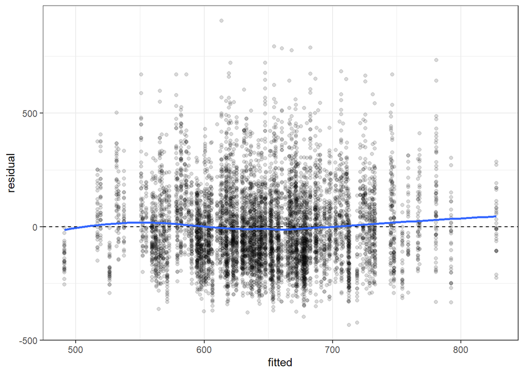

```r
workflow_diag <- data.frame(
  fitted = fitted(m_workflow),
  residual = residuals(m_workflow)
)

ggplot(
  workflow_diag,
  aes(x = fitted, y = residual)
) +
  geom_point(alpha = .15) +
  geom_hline(
    yintercept = 0,
    linetype = "dashed"
  ) +
  geom_smooth(
    method = "loess",
    formula = y ~ x,
    se = FALSE
  ) +
  theme_bw()
```

```r
check_collinearity(m_workflow)
```

```
# Check for Multicollinearity

Low Correlation

            Term  VIF   VIF 95% CI adj. VIF Tolerance Tolerance 95% CI
     frequency_z 4.69 [4.50, 4.89]     2.17      0.21     [0.20, 0.22]
        length_z 1.54 [1.49, 1.59]     1.24      0.65     [0.63, 0.67]
 neighbourhood_z 4.27 [4.10, 4.45]     2.07      0.23     [0.22, 0.24]
       condition 1.00 [1.00,     ]     1.00      1.00     [    , 1.00]
```

```r
std_resid_workflow <- rstandard(
  m_workflow
)

cook_workflow <- cooks.distance(
  m_workflow
)

head(
  order(
    abs(std_resid_workflow),
    decreasing = TRUE
  )
)
```

```
[1] 6495 6803 1255 4191 6747 6549
```

```r
head(
  order(
    cook_workflow,
    decreasing = TRUE
  )
)
```

```
[1] 6495 3757 6549 3792  798 6192
```

Ein wichtiger Befund dürfte die bereits bekannte Kollinearität zwischen lexikalischen Maßen sein.

Die angemessene Reaktion hängt aber von der Forschungsfrage ab: Wenn gerade die **einzigartigen Beiträge** von Frequency und Neighbourhood interessieren, kann es sinnvoll sein, beide trotz Kollinearität im Modell zu behalten und die größere Unsicherheit transparent zu berücksichtigen.

Das zentrale Ziel der Aufgabe ist deshalb nicht ein bestimmtes „bereinigtes finales Modell“, sondern eine **begründete Diagnose**.

# 7 Transfer: neuer Datensatz

Wir wechseln zum Datensatz `data_c` aus dem Paket **SfL**. Er enthält Daten zur unvollständigen Neutralisierung mit Vokaldauer als kontinuierlicher abhängiger Variable.

```r
data(data_c)

str(data_c)
```

```
'data.frame':   300 obs. of  9 variables:
 $ subject          : int  14 10 2 14 15 16 1 5 14 2 ...
 $ gender           : Factor w/ 2 levels "female","male": 1 2 2 1 2 2 1 1 1 2 ...
 $ item             : Factor w/ 48 levels "blode","blote",..: 42 29 10 44 32 44 2 8 17 37 ...
 $ voicing          : Factor w/ 2 levels "voiced","voiceless": 2 1 2 2 2 2 2 2 1 1 ...
 $ vowel            : Factor w/ 5 levels "a","au","i","o",..: 3 3 4 5 5 5 4 1 4 4 ...
 $ place            : Factor w/ 3 levels "alveolar","labial",..: 3 3 3 3 3 3 1 1 2 3 ...
 $ accent_type      : Factor w/ 2 levels "nuclear","prenuclear": 1 2 2 1 1 2 1 1 1 2 ...
 $ prosodic_boundary: Factor w/ 2 levels "no","yes": 2 1 1 2 2 1 1 2 2 1 ...
 $ vowel_dur        : num  166.9 97 95.3 151.4 100.5 ...
```

**WichtigTransfer 1 · Ein neues Modell selbst diagnostizieren**

Transfer

Untersuche die Frage:

> **Unterscheidet sich die Vokaldauer in Abhängigkeit vom Voicing des finalen Konsonanten?**

Gehe nicht sofort zum Modell, sondern arbeite den gesamten Workflow ab.

1. Verschaffe dir einen Überblick über die Daten.
2. Überlege, welche Variablen wiederholte Messungen bzw. Gruppierungsstrukturen anzeigen.
3. Formuliere ein geeignetes Mixed Model mit
   - `vowel_dur` als AV,
   - `voicing` als zentralem Fixed Effect,
   - sinnvollen Random Intercepts.
4. Schätze das Modell.
5. Prüfe
   - Output,
   - Residuen,
   - Konvergenz,
   - Singularität.
6. Entscheide, ob ein Random Slope für `voicing` innerhalb einer der Gruppierungsvariablen **durch das Design überhaupt sinnvoll schätzbar** wäre. Prüfe dazu die Datenstruktur, statt nur Syntax auszuprobieren.
7. Formuliere ein kurzes Diagnosefazit.

Es gibt hier bewusst nicht nur einen einzigen vertretbaren Modellweg.

**TippEine mögliche Herangehensweise**

Zunächst sollte die Datenstruktur geprüft werden:

```r
str(data_c)
```

```
'data.frame':   300 obs. of  9 variables:
 $ subject          : int  14 10 2 14 15 16 1 5 14 2 ...
 $ gender           : Factor w/ 2 levels "female","male": 1 2 2 1 2 2 1 1 1 2 ...
 $ item             : Factor w/ 48 levels "blode","blote",..: 42 29 10 44 32 44 2 8 17 37 ...
 $ voicing          : Factor w/ 2 levels "voiced","voiceless": 2 1 2 2 2 2 2 2 1 1 ...
 $ vowel            : Factor w/ 5 levels "a","au","i","o",..: 3 3 4 5 5 5 4 1 4 4 ...
 $ place            : Factor w/ 3 levels "alveolar","labial",..: 3 3 3 3 3 3 1 1 2 3 ...
 $ accent_type      : Factor w/ 2 levels "nuclear","prenuclear": 1 2 2 1 1 2 1 1 1 2 ...
 $ prosodic_boundary: Factor w/ 2 levels "no","yes": 2 1 1 2 2 1 1 2 2 1 ...
 $ vowel_dur        : num  166.9 97 95.3 151.4 100.5 ...
```

```r
table(
  data_c$subject,
  data_c$voicing
)
```

```
     voiced voiceless
  1       6        13
  2      11         8
  3       8        12
  4       9         6
  5       8        10
  6       5        10
  7       7        13
  8       8        11
  9       7         9
  10     13        10
  11      7        10
  12      9        12
  13      9        11
  14      8        12
  15     14         7
  16     10         7
```

```r
table(
  data_c$item,
  data_c$voicing
)
```

```
           voiced voiceless
  blode         7         0
  blote         0         9
  drude         8         0
  drute         0         6
  flabe         5         0
  flape         0         8
  frade         3         0
  frate         0         9
  froge         9         0
  froke         0         3
  frube         5         0
  frupe         0         9
  gage          8         0
  gake          0         5
  gaude         7         0
  gaute         0         8
  gobe          5         0
  gope          0        10
  griede       10         0
  griete        0         4
  jiede         1         0
  jiete         0         6
  klabe         4         0
  klape         0         5
  mube          4         0
  mupe          0         5
  nauge         8         0
  nauke         0         8
  priege        4         0
  prieke        0         7
  pruge         3         0
  pruke         0         7
  quade         7         0
  quate         0         6
  quobe         9         0
  quope         0         6
  roge          8         0
  roke          0         5
  schmaube      5         0
  schmaupe      0         5
  schriege      5         0
  schrieke      0         5
  schuge        5         0
  schuke        0         9
  stauge        4         0
  stauke        0         9
  wiebe         5         0
  wiepe         0         7
```

Ein möglicher Ausgangspunkt ist:

```r
m_transfer <- lmer(
  vowel_dur ~
    voicing +
    (1 | subject) +
    (1 | item),
  data = data_c,
  REML = FALSE
)

summary(m_transfer)
```

```
Linear mixed model fit by maximum likelihood . t-tests use Satterthwaite's
  method [lmerModLmerTest]
Formula: vowel_dur ~ voicing + (1 | subject) + (1 | item)
   Data: data_c

     AIC      BIC   logLik deviance df.resid
  2842.0   2860.5  -1416.0   2832.0      295

Scaled residuals:
    Min      1Q  Median      3Q     Max
-3.3000 -0.5602 -0.0792  0.5510  2.8583

Random effects:
 Groups   Name        Variance Std.Dev.
 item     (Intercept) 778.9    27.91
 subject  (Intercept) 756.4    27.50
 Residual             414.4    20.36
Number of obs: 300, groups:  item, 48; subject, 16

Fixed effects:
                 Estimate Std. Error      df t value Pr(>|t|)
(Intercept)       156.280      9.136  39.211  17.106   <2e-16 ***
voicingvoiceless   -4.011      8.459  46.382  -0.474    0.638
---
Signif. codes:  0 '***' 0.001 '**' 0.01 '*' 0.05 '.' 0.1 ' ' 1

Correlation of Fixed Effects:
            (Intr)
voicngvclss -0.468
```

```r
isSingular(m_transfer)
```

```
[1] FALSE
```

Residualdiagnostik:

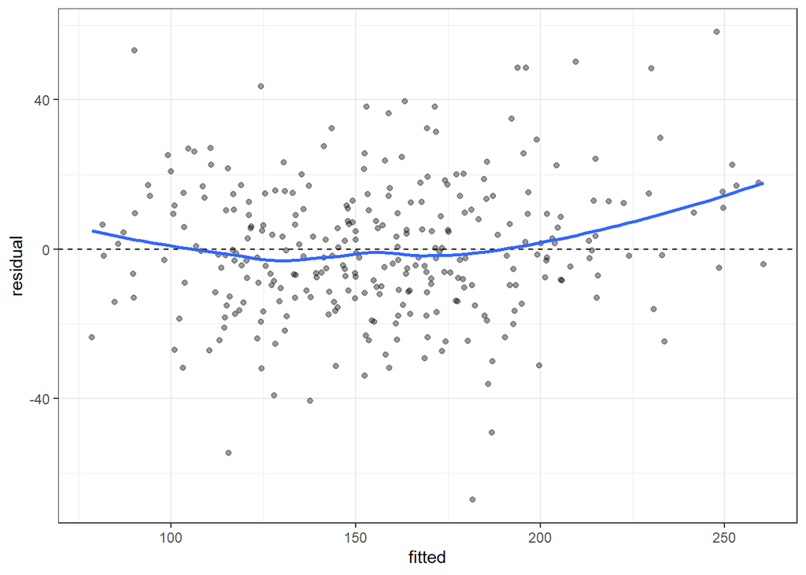

```r
transfer_diag <- data.frame(
  fitted = fitted(m_transfer),
  residual = residuals(m_transfer)
)

ggplot(
  transfer_diag,
  aes(x = fitted, y = residual)
) +
  geom_point(alpha = .4) +
  geom_hline(
    yintercept = 0,
    linetype = "dashed"
  ) +
  geom_smooth(
    method = "loess",
    formula = y ~ x,
    se = FALSE
  ) +
  theme_bw()
```

Ob ein Random Slope für `voicing` sinnvoll ist, sollte anhand der **within-group-Variation** entschieden werden.

Genau das ist der Transfer: Nicht

> „Mixed Model = überall möglichst viele Slopes“

sondern

> **Welche Variation erlaubt das Design tatsächlich zu schätzen?**

**HinweisExtra 5 · Sensitivitätsanalyse im Transferdatensatz**

extra

Identifiziere Beobachtungen mit besonders großen absoluten Residuen.

Entferne **nicht automatisch** Beobachtungen. Wähle stattdessen höchstens eine besonders auffällige Beobachtung für eine Sensitivitätsanalyse:

1. Ist der Datenpunkt plausibel?
2. Wie verändert sich der zentrale `voicing`-Koeffizient mit und ohne diese Beobachtung?
3. Bleibt deine wissenschaftliche Interpretation gleich?

**HinweisExtra 6 · Diagnosebericht statt Codebericht**

extra

Schreibe für eines der Modelle dieses Blocks einen kurzen Absatz, wie er in einer Methodik- oder Ergebnisdarstellung stehen könnte.

Der Absatz soll **nicht** bloß Funktionen aufzählen:

> „Wir haben `check_model()` und `cooks.distance()` verwendet.“

Sondern knapp beschreiben:

- welcher Befund geprüft wurde,
- ob etwas Auffälliges gefunden wurde,
- welche Sensitivitätsanalyse oder Modellanpassung vorgenommen wurde,
- und ob die zentrale Schlussfolgerung robust blieb.

**TippBeispiel**

Eine mögliche Formulierung wäre:

> Die Modelldiagnostik zeigte eine einzelne Beobachtung mit vergleichsweise hohem Einfluss auf die Parameterschätzung. Daher wurde das Modell zusätzlich ohne diese Beobachtung geschätzt. Die Größe des interessierenden Koeffizienten veränderte sich leicht, Richtung und inhaltliche Interpretation des Effekts blieben jedoch erhalten. Die Beobachtung wurde deshalb nicht aus der Hauptanalyse ausgeschlossen; die Sensitivitätsanalyse wurde ergänzend berichtet.

Die konkrete Formulierung muss natürlich zum tatsächlich diagnostizierten Modell passen.

# 8 Take-home

**WichtigWas soll nach diesem Block hängen bleiben?**

- **Signifikanz garantiert kein angemessenes Modell.**
- Residuen helfen zu erkennen, welche systematische Struktur ein Modell nicht erfasst.
- **Outlier, Leverage und Influence sind nicht dasselbe.**
- Cook’s Distance ist ein Diagnosehinweis, keine Löschregel.
- Robustheit bedeutet nicht identische Koeffizienten, sondern stabile wissenschaftliche Schlussfolgerungen unter plausiblen Analyseentscheidungen.
- Mehr Modellkomplexität ist nicht automatisch besser.
- Konvergenz und Singularität sind unterschiedliche Probleme.
- Bei Mixed Models müssen Modellvergleiche mit unterschiedlichen Fixed Effects auf einer geeigneten gemeinsamen Schätzgrundlage erfolgen.
- Auffälligkeiten sollten **begründet untersucht und transparent berichtet** werden.